# Regression and model validation

## Interpreting the fitted regression model

```r
#fit a linear regression model using points as the outcome and attitude, strategig and surface learning as explanatory variables
my_model <- lm(points ~ attitude + stra + surf, data = students2014)
summary(my_model)
```

```
##
## Call:
## lm(formula = points ~ attitude + stra + surf, data = students2014)
##
## Residuals:
##      Min       1Q   Median       3Q      Max
## -17.1550  -3.4346   0.5156   3.6401  10.8952
##
## Coefficients:
##             Estimate Std. Error t value Pr(>|t|)
## (Intercept)  11.0171     3.6837   2.991  0.00322 **
## attitude      3.3952     0.5741   5.913 1.93e-08 ***
## stra          0.8531     0.5416   1.575  0.11716
## surf         -0.5861     0.8014  -0.731  0.46563
## ---
## Signif. codes:  0 '***' 0.001 '**' 0.01 '*' 0.05 '.' 0.1 ' ' 1
##
## Residual standard error: 5.296 on 162 degrees of freedom
## Multiple R-squared:  0.2074, Adjusted R-squared:  0.1927
## F-statistic: 14.13 on 3 and 162 DF,  p-value: 3.156e-08
```

```r
#remove surface learning from the model, since it's so far from significant
my_model2 <- lm(points ~ attitude + stra, data = students2014)
summary(my_model2)
```

```
##
## Call:
## lm(formula = points ~ attitude + stra, data = students2014)
##
## Residuals:
##      Min       1Q   Median       3Q      Max
## -17.6436  -3.3113   0.5575   3.7928  10.9295
##
## Coefficients:
##             Estimate Std. Error t value Pr(>|t|)
## (Intercept)   8.9729     2.3959   3.745  0.00025 ***
## attitude      3.4658     0.5652   6.132 6.31e-09 ***
## stra          0.9137     0.5345   1.709  0.08927 .
## ---
## Signif. codes:  0 '***' 0.001 '**' 0.01 '*' 0.05 '.' 0.1 ' ' 1
##
## Residual standard error: 5.289 on 163 degrees of freedom
## Multiple R-squared:  0.2048, Adjusted R-squared:  0.1951
## F-statistic: 20.99 on 2 and 163 DF,  p-value: 7.734e-09
```

```r
#error rate
sigma(my_model2)*100/mean(students2014$points)
```

```
## [1] 23.28148
```

In the new model, p-value of the F-statistic is 7.734e-09. So at least one of the explanatory variables is significantly associated with exam points.

For attitude, p-value is <0.001, so it is significantly associated with exam points. According to this model, if attitude increases by 1, exam points increase by approximately 3.5.

The adjusted R-squared is 0.1951, which means that attitude (and strategic learning) only explain around 20% of the variance in exam points.

The residual standard error is 5.289 which corresponds to 23% prediction error rate.

## Assumptions of the model

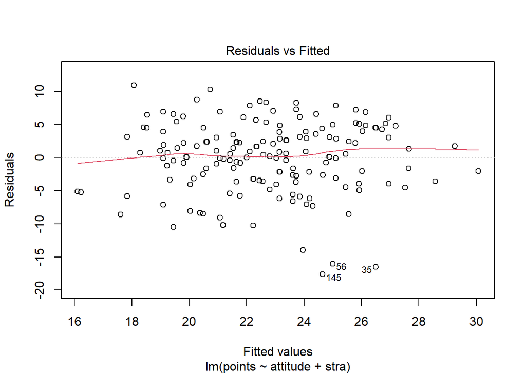

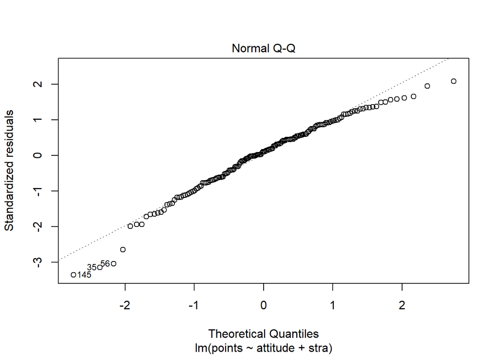

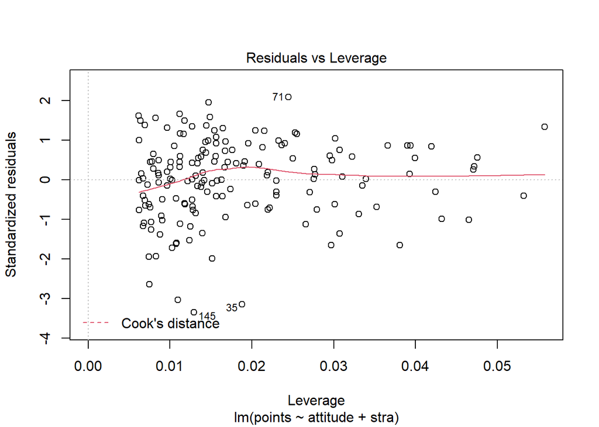

```r
plot(my_model2, which=c(1,2,5))
```

Linear regression assumes a linear relationship between predictors and outcome, that residual errors are normally distributed, that residuals have a constant variance, and independence of residual error terms.

With **Residuals vs. Fitted** plot we can check the linearity of data. Here, the red line seems to be horizontal at approximately zero, where it should be. So we can assume a linear relationship.

With plot **Normal Q-Q** we can check if residual errors are normally distributed. The plot of residuals should more or less follow the dashed line. Here they mostly do so, with some exceptions at the upper and lower ends. However, we may assume normality.

The **Residuals vs. Leverage** plot marks three most extreme points (35, 71, 145). Two of them exceed 3 standard deviations, so they are possible outliers.